# Bypassing LLM Safeguards With Homoglyphs

## Aldan Creo

[figure not shown]

https://github.com/ACMCMC/homoglyphs-workshop

# Some notes...

- This is a deep dive, will be a bit technical
- Will use code, you can download the repo to follow along - but don't have to!
- Don't need to know about AI, but can help

# Setup

1. Create a virtual environment:

   ```
   python -m venv env
   ```

2. Activate the virtual environment:
   - On Windows:

     ```
     .\env\Scripts\activate
     ```

   - On macOS/Linux:

     ```
     source env/bin/activate
     ```

3. Install the dependencies:

   ```
   pip install -r requirements.txt
   ```

# Homoglyphs 101

```python
CHAR_1 = "a"
CHAR_2 = "а"
```

```python
import unicodedata

print(CHAR_1 == CHAR_2)
print(unicodedata.name(CHAR_1))
print(CHAR_1.encode().hex())
print(unicodedata.name(CHAR_2))
print(CHAR_2.encode().hex())
```

```
False
LATIN SMALL LETTER A
61
CYRILLIC SMALL LETTER A
d0b0
```

# How does AI see the text?

```python
from datasets import load_dataset

# Load the dataset
dataset = load_dataset("silverspeak/writing_prompts", split='train')
display(dataset.to_pandas().head())
```

|  | text | model | generated |
| --- | --- | --- | --- |
| 0 | Detective Johnson leaned back in his chair, st... | gpt_prompt1 | True |
| 1 | *… fully operational. Repeat, the experiment i... | None | False |
| 2 | As the sun dipped below the horizon, casting e... | gpt_prompt1 | True |
| 3 | Once upon a time, in a world ravaged by chaos ... | gpt_writing | True |
| 4 | The man from the council stared blankly the an... | None | False |

```python
from tokenizers import Tokenizer, models, trainers, pre_tokenizers, normalizers


def initialize_tokenizer():
    # Initialize a Byte-Pair Encoding (BPE) tokenizer
    dummy_tokenizer = Tokenizer(models.BPE())

    # Set a normalizer to convert text to lowercase and strip accents
    dummy_tokenizer.normalizer = normalizers.Sequence(
        [normalizers.NFD(), normalizers.Lowercase(), normalizers.StripAccents()]
    )

    # Set a pre-tokenizer to split text into words - this ensures that the tokenizer operates at the word level
    dummy_tokenizer.pre_tokenizer = pre_tokenizers.Whitespace()

    return dummy_tokenizer
```

```python
# Prepare the trainer for the BPE tokenizer
trainer = trainers.BpeTrainer(vocab_size=5000)

# Extract text from the dataset
texts = [item["text"] for item in dataset]

# Train the tokenizer on the dataset's text
dummy_tokenizer_small = initialize_tokenizer()
dummy_tokenizer_small.train_from_iterator(texts[:10], trainer)

# Train the tokenizer on the dataset's text
dummy_tokenizer_full = initialize_tokenizer()
dummy_tokenizer_full.train_from_iterator(texts, trainer)
```

```python
# See how the tokenizer behaves before training
sentence = "What's the weather in Sofia? Currently, it's a bit cloudy."

tokenized_small = dummy_tokenizer_small.encode(sentence)
tokenized_full = dummy_tokenizer_full.encode(sentence)

# Display the tokens before and after training
print("Tokens after training with 10 texts:", tokenized_small.tokens, tokenized_small.ids)
print(
    "Tokens after training with all texts:", tokenized_full.tokens, tokenized_full.ids
)
```

```
Tokens after training with 10 texts: ['what', "'", 's', 'the', 'we', 'a', 'ther', 'in', 'sof', 'ia', '?', 'cur', 're', 'n', 'tly', ',', 'it', "'", 's', 'a', 'bit', 'cloud', 'y', '.'] [246, 3, 37, 50, 142, 19, 171, 49, 752, 972, 18, 250, 55, 32, 1024, 7, 70, 3, 37, 19, 1442, 2481, 43, 9]
Tokens after training with all texts: ['what', "'", 's', 'the', 'weather', 'in', 'sof', 'ia', '?', 'curren', 'tly', ',', 'it', "'", 's', 'a', 'bit', 'cloud', 'y', '.'] [268, 6, 56, 102, 4540, 101, 1319, 971, 30, 2650, 1320, 11, 118, 6, 56, 38, 902, 2822, 62, 13]
```

```python
print(list(dummy_tokenizer_small.get_vocab().items())[:5])
print(list(dummy_tokenizer_full.get_vocab().items())[:5])
```

```
[('bing', 1438), ('slight', 1695), ('mber', 2647), ('happ', 592), ('bed', 922)]
[('others', 894), ('police', 2714), ('ϡ', 74), ('ticul', 3078), ('abo', 1270)]
```

```python
import silverspeak

# See how the tokenizer behaves before training
sentence_replaced = silverspeak.random_attack(
    sentence, percentage=0.1, types_of_homoglyphs_to_use=["identical"]
)

print(sentence)

tokenized_full_attacked = dummy_tokenizer_full.encode(sentence_replaced)

print(
    "Tokens before attack:", tokenized_full.tokens, tokenized_full.ids
)
print(
    "Tokens after attack:", tokenized_full_attacked.tokens, tokenized_full_attacked.ids
)
```

```
What's the weather in Sofia? Currently, it's a bit cloudy.
Tokens before attack: ['what', "'", 's', 'the', 'weather', 'in', 'sof', 'ia', '?', 'curren', 'tly', ',', 'it', "'", 's', 'a', 'bit', 'cloud', 'y', '.'] [268, 6, 56, 102, 4540, 101, 1319, 971, 30, 2650, 1320, 11, 118, 6, 56, 38, 902, 2822, 62, 13]
Tokens after attack: ['wat', "'", 's', 'te', 'weather', 'n', 'of', 'ia', '?', 'curren', 'tly', ',', 'it', "'", 's', 'a', 'b', 't', 'cloud', 'y', '.'] [475, 6, 56, 209, 4540, 51, 121, 971, 30, 2650, 1320, 11, 118, 6, 56, 38, 39, 57, 2822, 62, 13]
```

# Detectors based on a classifier

```python
from transformers import AutoModelForSequenceClassification, AutoTokenizer

# Download the model and tokenizer
cl_model_name = "SJTU-CL/RoBERTa-large-ArguGPT"
cl_tokenizer = AutoTokenizer.from_pretrained(cl_model_name)
cl_model = AutoModelForSequenceClassification.from_pretrained(cl_model_name, device_map="auto")
```

```python
from sklearn.decomposition import PCA
import torch

# Take some random examples from the dataset
sampled_data = dataset.shuffle(seed=42).select(range(50))

def tokenize_and_get_embeddings(texts, tokenizer, model, max_length=128):
    # Tokenize the text data
    inputs = tokenizer(
        texts,
        padding=True,
        truncation=True,
        return_tensors="pt",
        max_length=max_length,
    )

    # Get embeddings from the model
    with torch.no_grad():
        embeddings = model.roberta(
            inputs["input_ids"].to(model.device), attention_mask=inputs["attention_mask"].to(model.device)
        ).last_hidden_state
        embeddings = embeddings.mean(dim=1).cpu()  # Mean pooling to get sentence embeddings

    return embeddings

# Example usage
embeddings = tokenize_and_get_embeddings(texts=sampled_data["text"], tokenizer=cl_tokenizer, model=cl_model)
```

# What embeddings look like

```python
print(embeddings[0])
print(embeddings[0].shape)
```

```
tensor([-0.1463,  0.4206, -0.7252,  ...,  0.1060, -0.8141,  0.4093])
torch.Size([1024])
```

# How can we "see" them?

## 👉 Dimensionality reduction

[figure not shown]

> Ranjbar-Khadivi, Mehrdad, et al. "Persian topic detection based on Human Word association and graph embedding." arXiv preprint arXiv:2302.09775 (2023).

```python
import matplotlib.pyplot as plt


def plot_pca_embeddings(embeddings, true_labels):
    # Apply PCA to reduce dimensions to 2D
    pca = PCA(n_components=2)
    reduced_embeddings = pca.fit_transform(embeddings.numpy())

    # Plot the reduced embeddings with true labels as colors
    plt.figure(figsize=(8, 6))
    for label in set(true_labels):
        indices = [i for i, l in enumerate(true_labels) if l == label]
        plt.scatter(
            reduced_embeddings[indices, 0],
            reduced_embeddings[indices, 1],
            label=f"Label {label}",
            alpha=0.7,
        )
    plt.legend()
    plt.title("PCA of the Samples")
    plt.xlabel("Principal Component 1")
    plt.ylabel("Principal Component 2")
    plt.grid()
    plt.show()
```

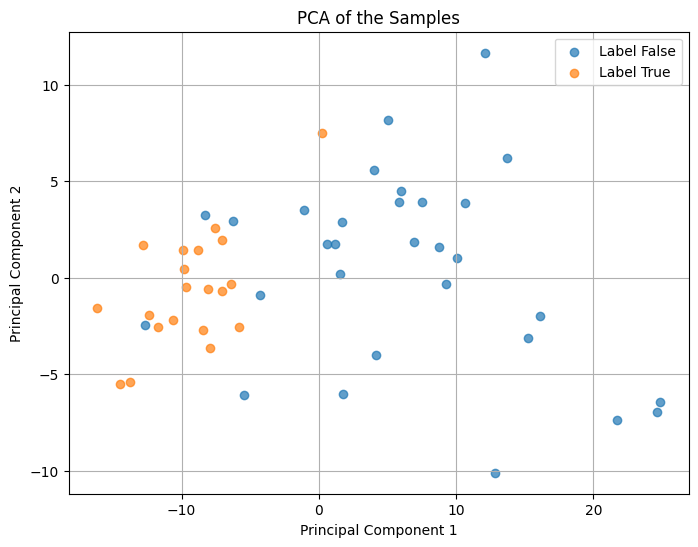

```python
plot_pca_embeddings(embeddings, true_labels=sampled_data["generated"])
```

## Let's replace with homoglyphs!

```python
import silverspeak

replaced_texts = sampled_data.map(
    lambda x: {
        "replaced_texts": silverspeak.random_attack(
            x["text"], percentage=0.15, types_of_homoglyphs_to_use=["identical"]
        )
    }
)
```

```python
# Tokenize and get embeddings for replaced texts
replaced_embeddings = tokenize_and_get_embeddings(
    texts=replaced_texts["replaced_texts"], tokenizer=cl_tokenizer, model=cl_model
)
```

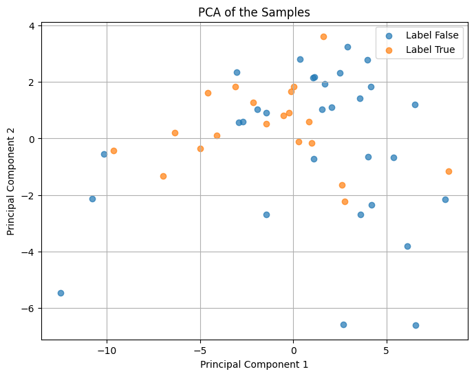

```python
# Apply PCA and plot embeddings for replaced texts
plot_pca_embeddings(replaced_embeddings, true_labels=sampled_data['generated'])
```

```python
# Apply PCA and plot embeddings for both types of texts at the same time (we'll have 4 classes now)
combined_embeddings = torch.cat([embeddings, replaced_embeddings], dim=0)
combined_labels = [f'O_{lab}' for lab in sampled_data['generated']] + [f'R_{lab}' for lab in sampled_data['generated']]
plot_pca_embeddings(combined_embeddings, combined_labels)
```

# Detectors based on perplexity

## Entropy

[figure not shown]

## Perplexity

$\text{Entropy} = - \sum_i p(x_i) \log p(x_i)$

```python
# Store entropy values for plotting
coin_entropy_values = []

# Calculate the entropy values for 100 possible coin heads-tails probabilities (from 0.0 to 1.0)
for p_heads in torch.linspace(0.0, 1.0, 100):
    p_heads = p_heads.item()
    p_tails = 1.0 - p_heads
    coin = torch.distributions.Categorical(
        probs=torch.tensor([p_heads, p_tails])
    )
    coin_entropy_values.append(coin.entropy().item())

# Plot the entropy values
plt.plot(torch.linspace(0.0, 1.0, 100).numpy(), coin_entropy_values, marker=None)
plt.title("Entropy vs Probability of Heads")
plt.xlabel("Probability of Heads")
plt.ylabel("Entropy")
plt.grid()
plt.show()
```

$\text{Cross-Entropy} = - \frac{1}{n} \sum_i^n p(pred_i) \log p(label_i)$

$ \text{Log-Perplexity} = - \frac{1}{n} \sum_{i=1}^n \log p(x_i) $

$\text{Perplexity} = e ^ {\text{Cross-Entropy}}$

$ \text{Log-Perplexity} = \log \left( e^{\text{Cross-Entropy}} \right) = \log \left( \text{Perplexity} \right) = \text{Cross-Entropy} $

*[Log-Perplexity is equivalent to Cross-Entropy as the logarithmic and exponential functions cancel each other out.]*

# Perplexity with real LLMs

```python
import transformers


gemma = transformers.AutoModelForCausalLM.from_pretrained(
    "google/gemma-3-1b-pt", device_map="auto"
)
gemma_tokenizer = transformers.AutoTokenizer.from_pretrained(
    "google/gemma-3-1b-pt", padding_side="left"
)
```

```python
from torch.nn.functional import cross_entropy


@torch.no_grad()
def perplexity(
    texts,
    model: transformers.PreTrainedModel,
    tokenizer: transformers.PreTrainedTokenizer,
):
    tokenized_texts = tokenizer(
        texts,
        padding="max_length",
        truncation=True,
        return_tensors="pt",
        return_attention_mask=True,
        return_special_tokens_mask=True,
        max_length=128,
    )

    logits = model(
        input_ids=tokenized_texts["input_ids"].to(model.device),
        attention_mask=tokenized_texts["attention_mask"].to(model.device),
    ).logits.cpu()

    shift_logits = logits[:, :-1, :].contiguous()
    shift_ids = tokenized_texts["input_ids"][:, 1:].contiguous()
    shift_attention_mask = tokenized_texts["attention_mask"][:, 1:].contiguous()
    loss_mask = shift_attention_mask & ~(tokenized_texts["special_tokens_mask"][:, 1:].contiguous())

    # Compute the cross-entropy loss for each token - be sure to ignore invalid positions where the attention mask is 0 (padding)
    per_token_ce = cross_entropy(
        shift_logits.view(-1, shift_logits.size(-1)),
        shift_ids.view(-1),
        reduction="none",
    ).view(shift_ids.size()) * loss_mask.bool()

    # Compute the mean perplexity across all valid tokens (where attention mask is 1)
    mean_perplexity = torch.exp(per_token_ce.sum(dim=1) / loss_mask.sum(dim=1))

    tokenized_texts_shifted = {
        "input_ids": shift_ids,
        "attention_mask": shift_attention_mask,
    }

    return per_token_ce, mean_perplexity, tokenized_texts_shifted
```

```python
# Get the perplexity of the first text
per_token_ce, mean_perplexity, tokenized_texts = perplexity(
    texts=[sentence],
    model=gemma,
    tokenizer=gemma_tokenizer,
)
print("Per-token CE:", per_token_ce[tokenized_texts['attention_mask'] == 1])
print("Mean perplexity:", mean_perplexity)
```

```python
import numpy as np

import matplotlib.pyplot as plt

def plot_per_token_ce(per_token_perplexity, tokenized_texts, tokenizer):
    # Decode the tokens back to text, ignoring positions where the attention mask is 0
    tokens = [
        tokenizer.decode([token_id])
        for token_id, mask in zip(tokenized_texts["input_ids"][0], tokenized_texts["attention_mask"][0])
        if mask == 1
    ]

    # Flatten the perplexity tensor and filter values where the attention mask is 0
    perplexity_values = [
        value for value, mask in zip(per_token_perplexity[0].tolist(), tokenized_texts["attention_mask"][0]) if mask == 1
    ]

    # Plot the perplexity values
    plt.figure(figsize=(12, 6))
    plt.bar(range(len(tokens)), perplexity_values, tick_label=tokens)
    plt.xticks(rotation=90)
    plt.title("Cross-Entropy Value of Each Token")
    plt.xlabel("Tokens")
    plt.ylabel("CE")
    plt.grid(axis='y', linestyle='--', alpha=0.7)
    plt.tight_layout()
    plt.show()
```

```python
plot_per_token_ce(per_token_ce, tokenized_texts, gemma_tokenizer)
```

```python
import tqdm

# Compute perplexities for the sampled texts in batches of 16 (so that we don't run out of memory)
batch_size = 16
sampled_per_token_cels = []
sampled_mean_perplexities = []

for i in tqdm.tqdm(range(0, len(sampled_data), batch_size)):
    batch_texts = sampled_data["text"][i : i + batch_size]
    per_token_ce, mean_perplexity, _ = perplexity(
        texts=batch_texts,
        model=gemma,
        tokenizer=gemma_tokenizer,
    )
    sampled_per_token_cels.append(per_token_ce)
    sampled_mean_perplexities.append(mean_perplexity)

sampled_per_token_cels = torch.cat(sampled_per_token_cels, dim=0)
sampled_mean_perplexities = torch.cat(sampled_mean_perplexities, dim=0)

# Display the mean perplexities for the sampled data
print("Mean perplexities for sampled data:", sampled_mean_perplexities)
```

```python
import numpy as np
import matplotlib.pyplot as plt


def plot_means_histogram(mean_perplexities, labels):
    # Add a small constant to avoid log(0) issues
    mean_perplexities = [mp + 1e-10 for mp in mean_perplexities]

    # Plot the histogram with a logarithmic scale
    plt.figure(figsize=(10, 6))
    plt.hist(
        [np.log10(mean_perplexities[i]) for i in range(len(labels)) if labels[i] == 0],
        bins=50,
        alpha=0.7,
        label="Not Generated",
        color="blue",
    )
    plt.hist(
        [np.log10(mean_perplexities[i]) for i in range(len(labels)) if labels[i] == 1],
        bins=50,
        alpha=0.7,
        label="Generated",
        color="orange",
    )
    plt.title("Histogram of Means Values")
    plt.xlabel("Log10(Mean)")
    plt.ylabel("Frequency")
    plt.legend()
    plt.grid(axis="y", linestyle="--", alpha=0.7)
    plt.show()
```

```python
plot_means_histogram(
    mean_perplexities=[mp.item() for mp in sampled_mean_perplexities],
    labels=sampled_data["generated"]
)
```

# Moving away from raw perplexity: cross-perplexity and Binoculars score

$\text{Cross-Perplexity}_{(M_1, M_2)}(text) = - \frac{1}{n} \sum_{i=1}^n M_1(text_i) \log M_2(text_i)$

⚠️ They need to have the same tokenizer!

```python
gemma_it = transformers.AutoModelForCausalLM.from_pretrained(
    "google/gemma-3-1b-it", device_map="auto"
)
```

```python
@torch.no_grad()
def cross_perplexity(
    texts,
    model_1: transformers.PreTrainedModel,
    model_2: transformers.PreTrainedModel,
    tokenizer: transformers.PreTrainedTokenizer,
    max_length=128,
    pad_token_id: int = 0,
    median: bool = False,
):
    # Tokenize the text data
    tokenized_texts = tokenizer(
        texts,
        padding="max_length",
        truncation=True,
        return_tensors="pt",
        return_attention_mask=True,
        max_length=max_length,
    )

    # Get logits from model_1
    logits_model_1 = model_1(
        input_ids=tokenized_texts["input_ids"].to(model_1.device),
        attention_mask=tokenized_texts["attention_mask"].to(model_1.device),
    ).logits.cpu()

    # Get logits from model_2
    logits_model_2 = model_2(
        input_ids=tokenized_texts["input_ids"].to(model_2.device),
        attention_mask=tokenized_texts["attention_mask"].to(model_2.device),
    ).logits.cpu()

    # Compute probabilities from logits (normalization)
    probabilities_1 = torch.nn.functional.softmax(logits_model_1, dim=-1)

    # Compute cross-perplexity as the cross-entropy loss between the logits of model 2 and the probabilities of each token ID according to model 1
    ce_loss = torch.nn.functional.cross_entropy(
        logits_model_2.view(-1, logits_model_2.size(-1)),
        probabilities_1.view(-1, probabilities_1.size(-1)),
        reduction="none",
    ).view(logits_model_2.size()[:-1])

    per_token_cross_perplexity = ce_loss * tokenized_texts["attention_mask"].bool()

    mean_cross_perplexity = (
        (
            (per_token_cross_perplexity).sum(dim=1)
            / tokenized_texts["attention_mask"].sum(dim=1)
        )
    )

    return per_token_cross_perplexity, mean_cross_perplexity, tokenized_texts
```

```python
import tqdm

# Compute perplexities for the sampled texts in batches of 16 (so that we don't run out of memory)
batch_size = 16
sampled_per_token_cross_perplexities = []
sampled_mean_cross_perplexities = []

for i in tqdm.tqdm(range(0, len(sampled_data), batch_size)):
    batch_texts = sampled_data["text"][i : i + batch_size]
    per_token_cross_perplexity, mean_cross_perplexity, _ = cross_perplexity(
        texts=batch_texts,
        model_1=gemma_it,
        model_2=gemma,
        tokenizer=gemma_tokenizer,
    )
    sampled_per_token_cross_perplexities.append(per_token_cross_perplexity)
    sampled_mean_cross_perplexities.append(mean_cross_perplexity)

sampled_per_token_cross_perplexities = torch.cat(sampled_per_token_cross_perplexities, dim=0)
sampled_mean_cross_perplexities = torch.cat(sampled_mean_cross_perplexities, dim=0)

# Display the mean perplexities for the sampled data
print("Mean cross perplexities for sampled data:", sampled_mean_cross_perplexities)
```

```python
plot_means_histogram(
    mean_perplexities=[mp.item() for mp in sampled_mean_cross_perplexities],
    labels=sampled_data["generated"]
)
```

# Bringing both metrics together

## Perplexity or cross-perplexity can be improved – a ratio of both tends to work better!

> Hans, Abhimanyu, et al. "Spotting llms with binoculars: Zero-shot detection of machine-generated text." arXiv preprint arXiv:2401.12070 (2024).

```python
# Calculate the ratio for each text
ratios = sampled_mean_perplexities / sampled_mean_cross_perplexities

print("Ratios for each text:", ratios)
```

```python
# Plot the histogram of ratios with corresponding labels
plot_means_histogram(
    mean_perplexities=[ratio.item() for ratio in ratios],
    labels=sampled_data["generated"]
)
```

# Homoglyph attacks

## What happens to perplexity, cross-perplexity and their ratio when we use homoglyphs?

```python
import silverspeak

replaced_texts = sampled_data.map(
    lambda x: {
        "replaced_texts": silverspeak.random_attack(
            x["text"], percentage=0.15, types_of_homoglyphs_to_use=["identical"]
        )
    }
)
```

```python
# Regenerate perplexities for the replaced texts in batches of 16
batch_size = 16
sampled_per_token_cels = []
sampled_mean_perplexities = []

for i in tqdm.tqdm(range(0, len(sampled_data), batch_size)):
    batch_texts = replaced_texts["replaced_texts"][i : i + batch_size]
    per_token_ce, mean_perplexity, _ = perplexity(
        texts=batch_texts,
        model=gemma,
        tokenizer=gemma_tokenizer,
    )
    sampled_per_token_cels.append(per_token_ce)
    sampled_mean_perplexities.append(mean_perplexity)

sampled_per_token_cels = torch.cat(sampled_per_token_cels, dim=0)
sampled_mean_perplexities = torch.cat(sampled_mean_perplexities, dim=0)
```

```python
# Regenerate cross-perplexities for the replaced texts in batches of 16
batch_size = 16
sampled_per_token_cross_perplexities = []
sampled_mean_cross_perplexities = []

for i in tqdm.tqdm(range(0, len(replaced_texts), batch_size)):
    batch_texts = replaced_texts["replaced_texts"][i : i + batch_size]
    per_token_cross_perplexity, mean_cross_perplexity, _ = cross_perplexity(
        texts=batch_texts,
        model_1=gemma_it,
        model_2=gemma,
        tokenizer=gemma_tokenizer,
    )
    sampled_per_token_cross_perplexities.append(per_token_cross_perplexity)
    sampled_mean_cross_perplexities.append(mean_cross_perplexity)

sampled_per_token_cross_perplexities = torch.cat(sampled_per_token_cross_perplexities, dim=0)
sampled_mean_cross_perplexities = torch.cat(sampled_mean_cross_perplexities, dim=0)
```

```python
# Regenerate the ratios
ratios = sampled_mean_perplexities / sampled_mean_cross_perplexities

print("Regenerated Ratios:", ratios)
```

```python
plot_means_histogram(
    mean_perplexities=[mp.item() for mp in sampled_mean_perplexities],
    labels=sampled_data["generated"]
)
```

```python
plot_means_histogram(
    mean_perplexities=[mp.item() for mp in sampled_mean_cross_perplexities],
    labels=sampled_data["generated"]
)
```

```python
plot_means_histogram(
    mean_perplexities=[r.item() for r in ratios],
    labels=sampled_data["generated"],
)
```

# Advanced Homoglyphs

## Unicode Normal Forms

[figure not shown]

*(source: unicode.org)*

## Beyond English

## Up till this point, we've analyzed homoglyphs for English characters that we take from other languages...

## But what happens when we consider other languages?

[figure not shown]

# *Quantifying Character Similarity with Vision Transformers*

## Xinmei Yang, Abhishek Arora, Shao-Yu Jheng, Melissa Dell

```python
from IPython.display import Markdown, display

HZ_CHAR_1 = "言"
HZ_CHAR_2 = "訁"

display(Markdown(f"# {HZ_CHAR_1}"))
display(Markdown(f"# {HZ_CHAR_2}"))
display(HZ_CHAR_1 == HZ_CHAR_2)
```

```python
import unicodedata

display(unicodedata.name(HZ_CHAR_1))
display(unicodedata.name(HZ_CHAR_2))
display(unicodedata.is_normalized('NFKD', HZ_CHAR_1))
display(unicodedata.is_normalized('NFKD', HZ_CHAR_2))
```

```python
display(unicodedata.east_asian_width(HZ_CHAR_1))
display(unicodedata.east_asian_width(HZ_CHAR_2))
```

*...so how can we tell them apart?*